# R Quick Tour

Chris Chapman, Google  
February 2016

**Analytics with Purpose Conference**  
Scottsdale, AZ

### Basics of R

Key Points

- It's where new methods are developed first
- Over 8000 add on packages and tools
- It is open source and free to use (except occasional packages)
- Don't think of R as a “statistics program.''
- R is primarily a *programming language*

### Reasons to Use R

- For the latest statistics methods
- For maximum power to develop your own analyses
- It excels for iteration and automation
- Large community support for advanced analytics
- It's free
- Includes integrating reporting capabilities (such as these slides)

### Reasons not to Use R

- It requires programming to do most analyses
- Routine analyses are more difficult at first
- Charting and plotting are not easy, and tend to be rather basic unless they are tweaked substantially

### GUI Tour

- R base
- R Studio

Switch to RStudio and look at the elements of the R IDE (integrated development environment)

### Customer Satifaction Data (simulated)

We'll use a data set from Chapman & Feit (2015).

- CSat survey with 4 items
- 2 Satisfaction items: with Product & Sales
- 2 Likelihood to recommend items: Product & Sales
- Each item assessed on 7 point Likert scale

### Customer Satifaction Model

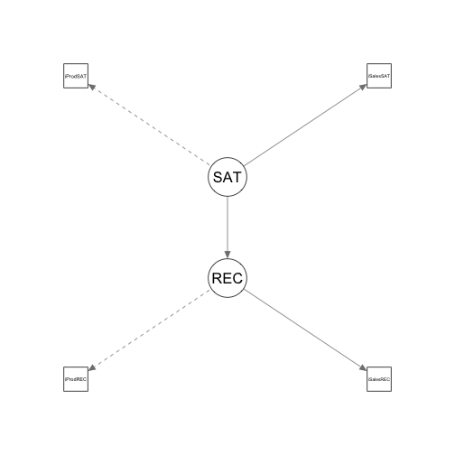

### Code

Let's switch to R and walk through some typical code …

```r
satData <- read.csv("http://r-marketing.r-forge.r-project.org/data/rintro-chapter2.csv")

# examine the data
head(satData)
str(satData)
summary(satData)

# convert Segment to a factor variable
satData$Segment <- factor(satData$Segment)
summary(satData)

# Satisfaction by segment
library(ggplot2)
by(satData$iProdSAT, satData$Segment, mean_se, mult=1.96)


###### EXAMPLE OF PLOTTING

### first aggregate the data we want to plot
# ... there are other ways to do this, but this illustrates data frame manipulation

# get the mean and standard errors
prod.sat.seg <- aggregate(satData$iProdSAT, list(satData$Segment), mean_se, mult=1.96)
str(prod.sat.seg)

# coerce those to a nice data frame
prod.sat.seg <- data.frame(prod.sat.seg$Group.1, lapply(data.frame(prod.sat.seg$x), unlist))
prod.sat.seg

# and label the columns to be more readable
names(prod.sat.seg) <- c("Segment", "average", "lowerCI", "upperCI")
prod.sat.seg

### the plot itself ...

# now plot the interquartile range
p <- ggplot(data=prod.sat.seg,
            aes(x=Segment, y=average, ymax=upperCI, ymin=lowerCI)) +
     geom_point() +
     geom_errorbar()

p

# color the points and make them larger
p <- ggplot(data=prod.sat.seg,
            aes(x=Segment, y=average, ymax=upperCI, ymin=lowerCI)) +
     geom_point(aes(color=Segment), size=3) +      # <=======
     geom_errorbar()

p

# color the error bars and make them narrower
p <- ggplot(data=prod.sat.seg,
            aes(x=Segment, y=average, ymax=upperCI, ymin=lowerCI)) +
     geom_point(aes(color=Segment), size=3) +
     geom_errorbar(aes(color=Segment), width=0.3)      # <=======

p

# adjust the Y axis range
p <- ggplot(data=prod.sat.seg,
            aes(x=Segment, y=average, ymax=upperCI, ymin=lowerCI)) +
     geom_point(aes(color=Segment), size=3) +
     geom_errorbar(aes(color=Segment), width=0.3) +
     coord_cartesian(ylim=c(1, 5))    # <========

p

# add some titles to be more readable
p <- ggplot(data=prod.sat.seg,
            aes(x=Segment, y=average, ymax=upperCI, ymin=lowerCI)) +
     geom_point(aes(color=Segment), size=3) +
     geom_errorbar(aes(color=Segment), width=0.3) +
     coord_cartesian(ylim=c(1, 5)) +
     ggtitle("Average Sat and Confidence Interval by Segment") +    # <=====
     ylab("Mean satisfaction and 95% CI")

p


########## CORRELATIONS

# correlation matrix
library(corrplot)
corrplot(cor(satData[ , -3]))

# tinker with the plot
corrplot.mixed(cor(satData[ , -3]))


#### ADVANCED MODELING. EXAMPLE: SAT/REC STRUCTURAL MODEL

# define a structural model for Satisfaction and Recommendation
satModel <- "SAT =~ iProdSAT + iSalesSAT
             REC =~ iProdREC + iSalesREC
             REC ~  SAT "

# fit the structural model
library(lavaan)
sat.fit <- cfa(satModel, data=satData)

# look at the fit
summary(sat.fit, fit.measures=TRUE)

# plot the structural model
library(semPlot)
semPaths(sat.fit, what="est", nCharNodes=9, residuals=FALSE)
```

### Pros and Cons

**Pro**  
1. Extreme power and precision. It does exactly what you want.  
2. Complete flexibility at every step  
3. Once script is done it is reusable and re-runnable

**Con**  
1. It only does exactly what you tell it. Defaults are missing or ugly.  
2. You have to write code.  
3. Everything takes longer … the *first* time.

### Next Steps

1. Get R from r-project.org
2. Get RStudio from rstudio.com.
3. See starting points at [CRAN Task Views](https://cran.r-project.org/web/views/)
4. Get a tutorial (maybe this book?)

[figure not shown]

### The Most Important Things

To learn R, you will need:

- Skill or genuine interest in learning to **program**
- A **real data problem** that you need to solve
- Routine **methods that you understand** well (e.g., ANOVA, lm)
- **Time** to work through the steep learning curve
- **Discipline** to force yourself to finish the project!
- Ability to **iterate** on successive projects, as it gets easier and easier

Only try advanced/new methods after you are fluent in the basics.

### Q&A

Thank you!

Chris Chapman cchapman@google.com